# Gene Set Testing with CAMERA

Bioinformatics Tutorial

2025-11-03

# Introduction

This tutorial demonstrates how to perform **competitive gene set testing** using **CAMERA** (Correlation Adjusted MEan RAnk gene set test) from the `limma` package.

## What is CAMERA?

**CAMERA** is a competitive gene set test that:

- Tests whether genes in a pathway are **MORE differentially expressed** than genes **NOT in the pathway**
- Accounts for **inter-gene correlation**, which is crucial because genes in pathways often work together
- Provides directional enrichment (up or down-regulated pathways)
- Is generally more powerful than older methods like GSEA for microarray data

## Competitive vs Self-Contained Tests

- **Competitive tests (CAMERA)**: Compare genes in the set vs. genes outside the set
  - Question: “Are these genes MORE DE than other genes?”
  - Null hypothesis: Genes in set are no more DE than genes outside
- **Self-contained tests (ROAST/MROAST/FRY)**: Compare genes in the set vs. no differential expression
  - Question: “Are these genes DE?”
  - Null hypothesis: No genes in the set are DE

In this tutorial, we’ll use the **ALL (Acute Lymphoblastic Leukemia)** dataset to compare B-cell vs T-cell samples and identify enriched KEGG pathways.

# 1. Load Required Packages

We need several Bioconductor packages for this analysis:

```r
library(limma)
library(ALL)
library(hgu95av2.db)
library(org.Hs.eg.db)
library(clusterProfiler)
```

**Package purposes:**

- `limma`: Differential expression and CAMERA analysis
- `ALL`: The acute lymphoblastic leukemia dataset
- `hgu95av2.db`: Microarray platform annotations
- `org.Hs.eg.db`: Human gene annotations and KEGG pathways
- `clusterProfiler`: For downloading KEGG pathway descriptions

# 2. Load and Prepare the ALL Dataset

The ALL dataset contains gene expression profiles from patients with acute lymphoblastic leukemia. We’ll compare B-cell and T-cell subtypes.

```r
# Load the dataset
data(ALL)

# Examine the dataset structure
print(ALL)
```

```
## ExpressionSet (storageMode: lockedEnvironment)
## assayData: 12625 features, 128 samples
##   element names: exprs
## protocolData: none
## phenoData
##   sampleNames: 01005 01010 ... LAL4 (128 total)
##   varLabels: cod diagnosis ... date last seen (21 total)
##   varMetadata: labelDescription
## featureData: none
## experimentData: use 'experimentData(object)'
##   pubMedIds: 14684422 16243790
## Annotation: hgu95av2
```

```r
# View sample information
print("Sample phenotype data (first 5 samples, first 5 columns):")
```

```
## [1] "Sample phenotype data (first 5 samples, first 5 columns):"
```

```r
print(pData(ALL)[1:5, 1:5])
```

```
##        cod diagnosis sex age BT
## 01005 1005 5/21/1997   M  53 B2
## 01010 1010 3/29/2000   M  19 B2
## 03002 3002 6/24/1998   F  52 B4
## 04006 4006 7/17/1997   M  38 B1
## 04007 4007 7/22/1997   M  57 B2
```

## 2.1 Select Samples for Comparison

We’ll focus on comparing B-cell and T-cell ALL samples.

```r
# Identify B-cell samples (includes B, B1, B2, B3, B4 subtypes)
bcell_samples <- which(ALL$BT %in% c("B", "B1", "B2", "B3", "B4"))

# Identify T-cell samples
tcell_samples <- which(ALL$BT == "T")

# Create a subset with B-cell and T-cell samples
# Using 10 B-cell and all T-cell samples for a balanced comparison
samples_to_keep <- c(bcell_samples[1:10], tcell_samples)
ALL_subset <- ALL[, samples_to_keep]

cat("Number of samples selected:\n")
```

```
## Number of samples selected:
```

```r
cat("  B-cell samples:", length(bcell_samples[1:10]), "\n")
```

```
##   B-cell samples: 10
```

```r
cat("  T-cell samples:", length(tcell_samples), "\n")
```

```
##   T-cell samples: 5
```

```r
cat("  Total:", length(samples_to_keep), "\n")
```

```
##   Total: 15
```

# 3. Preprocessing and Design Matrix

We extract the expression data and create a design matrix for the linear model.

```r
# Extract expression data
exprs_data <- exprs(ALL_subset)

# Create cell type factor
cell_type <- factor(ifelse(ALL_subset$BT == "T", "T", "B"))

# Create design matrix (group-means parameterization)
design <- model.matrix(~0 + cell_type)
colnames(design) <- c("B_cell", "T_cell")

cat("Design matrix structure:\n")
```

```
## Design matrix structure:
```

```r
print(head(design))
```

```
##   B_cell T_cell
## 1      1      0
## 2      1      0
## 3      1      0
## 4      1      0
## 5      1      0
## 6      1      0
```

```r
cat("\nSample distribution:\n")
```

```
##
## Sample distribution:
```

```r
print(table(cell_type))
```

```
## cell_type
##  B  T
## 10  5
```

**Design matrix notes:**

- We use `~0 + cell_type` for a group-means parameterization
- This makes it easier to specify contrasts between groups
- Each column represents one cell type

# 4. Differential Expression Analysis

We use `limma` to identify differentially expressed genes between T-cell and B-cell samples.

```r
# Fit linear model
fit <- lmFit(exprs_data, design)

# Define contrast: T-cell vs B-cell
contrast_matrix <- makeContrasts(
  TvsB = T_cell - B_cell,
  levels = design
)

cat("Contrast matrix:\n")
```

```
## Contrast matrix:
```

```r
print(contrast_matrix)
```

```
##         Contrasts
## Levels   TvsB
##   B_cell   -1
##   T_cell    1
```

```r
# Fit contrasts and apply empirical Bayes moderation
fit2 <- contrasts.fit(fit, contrast_matrix)
fit2 <- eBayes(fit2)

# View top differentially expressed genes
top_genes <- topTable(fit2, coef = "TvsB", number = 20)

cat("\nTop 20 differentially expressed genes:\n")
```

```
##
## Top 20 differentially expressed genes:
```

```r
print(top_genes[, c("logFC", "AveExpr", "t", "P.Value", "adj.P.Val")])
```

```
##                logFC   AveExpr          t      P.Value    adj.P.Val
## 38319_at    4.483282  6.385744  13.829293 3.094569e-10 3.906894e-06
## 38147_at    2.726426  4.519145  12.825759 9.269009e-10 5.851062e-06
## 2031_s_at  -3.292335  8.801557 -11.095824 7.347931e-09 3.092254e-05
## 37039_at   -2.678274 11.234888  -9.753845 4.397852e-08 1.388072e-04
## 41723_s_at -3.354824  8.195279  -8.804350 1.746216e-07 4.409197e-04
## 41409_at   -1.954163  7.165671  -8.589302 2.420616e-07 4.421542e-04
## 2059_s_at   2.228525  7.176821   8.581013 2.451548e-07 4.421542e-04
## 38095_i_at -3.272734 10.384079  -8.465467 2.928754e-07 4.621940e-04
## 266_s_at   -3.522492  7.100962  -8.141603 4.863535e-07 5.729679e-04
## 32506_at   -1.204799  6.644397  -8.103231 5.169197e-07 5.729679e-04
## 32842_at   -1.786812  7.956271  -8.087330 5.301713e-07 5.729679e-04
## 38096_f_at -3.505889  9.618419  -8.070480 5.446031e-07 5.729679e-04
## 41468_at    3.449934  7.576728   7.679060 1.026687e-06 9.931685e-04
## 32793_at    2.463675  8.432056   7.636465 1.101335e-06 9.931685e-04
## 1110_at     3.625333  6.993577   7.592573 1.184230e-06 9.967271e-04
## 33238_at    2.652044  7.271808   7.516535 1.343675e-06 1.060243e-03
## 38833_at   -2.579441 10.288284  -7.334979 1.822289e-06 1.324982e-03
## 40473_at   -1.218719  9.134394  -7.288674 1.970921e-06 1.324982e-03
## 35016_at   -2.684294 10.388821  -7.281804 1.994032e-06 1.324982e-03
## 36773_f_at -2.572337  8.137303  -7.104531 2.699720e-06 1.704199e-03
```

**Key statistics:**

- **logFC**: Log2 fold change (T-cell vs B-cell)
- **AveExpr**: Average expression across all samples
- **t**: Moderated t-statistic
- **P.Value**: Raw p-value
- **adj.P.Val**: FDR-adjusted p-value (Benjamini-Hochberg)

# 5. Prepare KEGG Pathway Gene Sets

Gene set testing requires mapping microarray probes to genes and then to pathways.

## 5.1 Map Probes to Entrez Gene IDs

```r
# Get probe to Entrez Gene ID mapping from the array annotation
probe_to_entrez <- as.list(hgu95av2ENTREZID)
probe_to_entrez <- probe_to_entrez[!is.na(probe_to_entrez)]

# Map our probes to Entrez IDs
probe_ids <- rownames(exprs_data)
entrez_mapping <- unlist(probe_to_entrez[probe_ids])
entrez_mapping <- entrez_mapping[!is.na(entrez_mapping)]

cat("Probe to gene mapping:\n")
```

```
## Probe to gene mapping:
```

```r
cat("  Total probes in dataset:", length(probe_ids), "\n")
```

```
##   Total probes in dataset: 12625
```

```r
cat("  Probes mapped to Entrez IDs:", length(entrez_mapping), "\n")
```

```
##   Probes mapped to Entrez IDs: 11683
```

```r
cat("  Mapping rate:", round(100 * length(entrez_mapping) / length(probe_ids), 1), "%\n")
```

```
##   Mapping rate: 92.5 %
```

## 5.2 Get KEGG Pathway Annotations

We use `org.Hs.egPATH` to map Entrez Gene IDs to KEGG pathway IDs.

```r
# Get gene-to-pathway mapping
pathway_map <- org.Hs.egPATH
mapped_genes <- mappedkeys(pathway_map)
gene_to_pathway <- as.list(pathway_map[mapped_genes])

cat("Gene-to-pathway mapping:\n")
```

```
## Gene-to-pathway mapping:
```

```r
cat("  Total genes mapped to pathways:", length(gene_to_pathway), "\n")
```

```
##   Total genes mapped to pathways: 5868
```

```r
cat("  Example - first gene:", names(gene_to_pathway)[1], "\n")
```

```
##   Example - first gene: 2
```

```r
cat("  Pathways for this gene:", paste(gene_to_pathway[[1]], collapse = ", "), "\n")
```

```
##   Pathways for this gene: 04610
```

## 5.3 Invert to Pathway-to-Genes Mapping

CAMERA requires a list where each pathway contains its member genes.

```r
# Create pathway-to-genes mapping
pathway_to_genes <- list()

for (gene_id in names(gene_to_pathway)) {
  pathways <- gene_to_pathway[[gene_id]]
  for (pathway_id in pathways) {
    if (is.null(pathway_to_genes[[pathway_id]])) {
      pathway_to_genes[[pathway_id]] <- character(0)
    }
    pathway_to_genes[[pathway_id]] <- c(pathway_to_genes[[pathway_id]], gene_id)
  }
}

cat("Pathway-to-genes mapping:\n")
```

```
## Pathway-to-genes mapping:
```

```r
cat("  Total KEGG pathways:", length(pathway_to_genes), "\n")
```

```
##   Total KEGG pathways: 229
```

```r
cat("  First few pathway IDs:", paste(names(pathway_to_genes)[1:5], collapse = ", "), "\n")
```

```
##   First few pathway IDs: 04610, 00232, 00983, 01100, 00380
```

## 5.4 Create Gene Set Index Lists

CAMERA requires pathways as lists of row indices in the expression matrix.

```r
create_gene_set_indices <- function(pathway_list, gene_mapping, min_genes = 10) {
  pathway_indices <- list()

  for (pathway_id in names(pathway_list)) {
    # Get genes in this pathway
    pathway_genes <- pathway_list[[pathway_id]]

    # Find probes that map to these genes
    probes_in_pathway <- names(gene_mapping)[gene_mapping %in% pathway_genes]

    # Get row indices of these probes in expression matrix
    indices <- which(rownames(exprs_data) %in% probes_in_pathway)

    # Only keep pathways with sufficient genes for statistical power
    if (length(indices) >= min_genes) {
      pathway_indices[[pathway_id]] <- indices
    }
  }

  return(pathway_indices)
}

gene_set_indices <- create_gene_set_indices(pathway_to_genes, entrez_mapping)

cat("Gene set indices for CAMERA:\n")
```

```
## Gene set indices for CAMERA:
```

```r
cat("  Pathways with ≥10 genes:", length(gene_set_indices), "\n")
```

```
##   Pathways with ≥10 genes: 210
```

```r
cat("  Example - Pathway", names(gene_set_indices)[1], "\n")
```

```
##   Example - Pathway 04610
```

```r
cat("    has", length(gene_set_indices[[1]]), "genes in the dataset\n")
```

```
##     has 73 genes in the dataset
```

**Why filter by pathway size?**

- Pathways with very few genes have limited statistical power
- Small gene sets may produce unreliable enrichment results
- A minimum of 10-15 genes is standard practice

# 6. Run CAMERA Analysis

CAMERA performs competitive gene set testing while accounting for inter-gene correlation.

```r
# Run CAMERA
camera_results <- camera(
  y = exprs_data,
  index = gene_set_indices,
  design = design,
  contrast = contrast_matrix[, "TvsB"],
  inter.gene.cor = 0.01
)

cat("CAMERA analysis complete!\n")
```

```
## CAMERA analysis complete!
```

```r
cat("  Pathways tested:", nrow(camera_results), "\n\n")
```

```
##   Pathways tested: 210
```

```r
cat("Top 15 enriched KEGG pathways:\n")
```

```
## Top 15 enriched KEGG pathways:
```

```r
print(head(camera_results, 15))
```

```
##       NGenes Direction       PValue          FDR
## 03010     81      Down 1.188895e-09 2.496680e-07
## 05310     35      Down 2.958238e-08 2.310987e-06
## 04612     90      Down 3.301411e-08 2.310987e-06
## 03040    136      Down 9.657140e-08 5.069998e-06
## 05131    100      Down 1.296692e-06 4.994151e-05
## 05322     98      Down 1.490195e-06 4.994151e-05
## 05332     48      Down 1.664717e-06 4.994151e-05
## 05140    111      Down 2.834588e-06 7.440794e-05
## 05330     51      Down 2.748009e-05 6.412020e-04
## 03050     50      Down 3.210918e-05 6.742929e-04
## 00982     71        Up 5.769479e-05 1.101446e-03
## 05130     83      Down 9.191080e-05 1.608439e-03
## 03013    134      Down 1.088055e-04 1.757628e-03
## 05416     99      Down 1.282019e-04 1.923028e-03
## 05100    108      Down 2.195612e-04 2.921721e-03
```

**CAMERA parameters:**

- **y**: Expression data matrix
- **index**: List of gene set indices
- **design**: Design matrix
- **contrast**: The contrast to test
- **inter.gene.cor**: Assumed inter-gene correlation
  - `0.01`: Small positive correlation (default assumption)
  - `NA`: Estimate from data (slower but more accurate)
  - Higher values: More conservative p-values

# 7. Annotate Results with Pathway Descriptions

Raw pathway IDs are not interpretable, so we’ll add pathway names and descriptions.

## 7.1 Download KEGG Pathway Information

```r
cat("Downloading KEGG pathway information...\n")
# Download KEGG data using clusterProfiler
kegg_info <- download_KEGG("hsa")

cat("\nStructure of downloaded data:\n")
```

```
##
## Structure of downloaded data:
```

```r
str(kegg_info)
```

```
## List of 2
##  $ KEGGPATHID2EXTID:'data.frame':    39690 obs. of  2 variables:
##   ..$ from: chr [1:39690] "hsa00010" "hsa00010" "hsa00010" "hsa00010" ...
##   ..$ to  : chr [1:39690] "10327" "124" "125" "126" ...
##  $ KEGGPATHID2NAME :'data.frame':    368 obs. of  2 variables:
##   ..$ from: chr [1:368] "hsa01100" "hsa01200" "hsa01210" "hsa01212" ...
##   ..$ to  : chr [1:368] "Metabolic pathways" "Carbon metabolism" "2-Oxocarboxylic acid metabolism" "Fatty acid metabolism" ...
```

The `kegg_info` object contains:

- **KEGGPATHID2EXTID**: Maps pathway IDs to gene Entrez IDs
- **KEGGPATHID2NAME**: Maps pathway IDs to pathway names

## 7.2 Create Pathway Name Mapping

```r
# Extract pathway names
pathway_names <- setNames(
  kegg_info$KEGGPATHID2NAME$to,
  kegg_info$KEGGPATHID2NAME$from
)

cat("Pathway name mapping:\n")
```

```
## Pathway name mapping:
```

```r
cat("  Total pathways with names:", length(pathway_names), "\n\n")
```

```
##   Total pathways with names: 368
```

```r
cat("Example pathway names:\n")
```

```
## Example pathway names:
```

```r
print(head(pathway_names, 3))
```

```
##                          hsa01100                          hsa01200
##              "Metabolic pathways"               "Carbon metabolism"
##                          hsa01210
## "2-Oxocarboxylic acid metabolism"
```

## 7.3 Format and Add Descriptions to Results

```r
# Get pathway IDs from CAMERA results
pathway_ids <- rownames(camera_results)

# Pad pathway IDs with leading zeros to match KEGG format
# Example: "810" becomes "00810", then "hsa00810"
pathway_ids_padded <- sprintf("%05s", pathway_ids)
pathway_ids_formatted <- paste0("hsa", pathway_ids_padded)

cat("Example of ID formatting:\n")
```

```
## Example of ID formatting:
```

```r
formatting_example <- data.frame(
  Original = head(pathway_ids),
  Padded = head(pathway_ids_padded),
  Formatted = head(pathway_ids_formatted)
)
print(formatting_example)
```

```
##   Original Padded Formatted
## 1    03010  03010  hsa03010
## 2    05310  05310  hsa05310
## 3    04612  04612  hsa04612
## 4    03040  03040  hsa03040
## 5    05131  05131  hsa05131
## 6    05322  05322  hsa05322
```

```r
# Add descriptions to results
camera_results$Description <- pathway_names[pathway_ids_formatted]

# Mark missing descriptions as NA
camera_results$Description[is.na(camera_results$Description)] <- NA

cat("\nDescriptions successfully added!\n\n")
```

```
##
## Descriptions successfully added!
```

```r
cat("Top 10 pathways with descriptions:\n")
```

```
## Top 10 pathways with descriptions:
```

```r
print(camera_results[1:10, c("NGenes", "Direction", "PValue", "FDR", "Description")])
```

```
##       NGenes Direction       PValue          FDR
## 03010     81      Down 1.188895e-09 2.496680e-07
## 05310     35      Down 2.958238e-08 2.310987e-06
## 04612     90      Down 3.301411e-08 2.310987e-06
## 03040    136      Down 9.657140e-08 5.069998e-06
## 05131    100      Down 1.296692e-06 4.994151e-05
## 05322     98      Down 1.490195e-06 4.994151e-05
## 05332     48      Down 1.664717e-06 4.994151e-05
## 05140    111      Down 2.834588e-06 7.440794e-05
## 05330     51      Down 2.748009e-05 6.412020e-04
## 03050     50      Down 3.210918e-05 6.742929e-04
##                               Description
## 03010                            Ribosome
## 05310                              Asthma
## 04612 Antigen processing and presentation
## 03040                         Spliceosome
## 05131                         Shigellosis
## 05322        Systemic lupus erythematosus
## 05332           Graft-versus-host disease
## 05140                       Leishmaniasis
## 05330                 Allograft rejection
## 03050                          Proteasome
```

**Why pad with zeros?**

- KEGG pathway IDs have 5 digits: “hsa00810”, “hsa01100”
- Our data may have IDs without leading zeros: “810”, “1100”
- We need to pad to match the KEGG format for lookup

# 8. Visualize Results

Visualization helps identify the most significant pathways and their direction of enrichment.

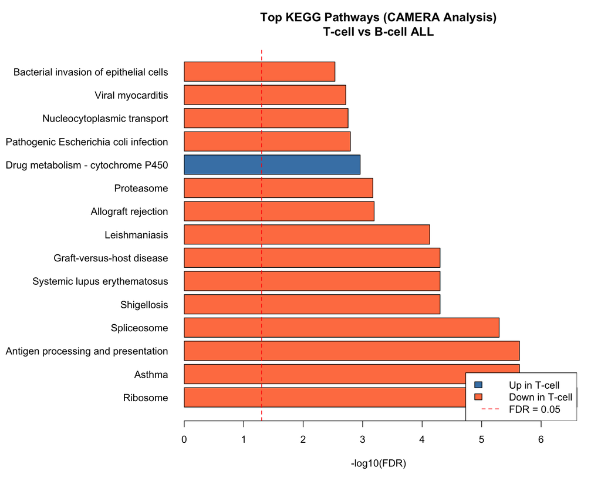

```r
# Select top pathways for visualization
top_n <- 15
top_pathways <- head(camera_results, top_n)

# Create barplot
par(mar = c(5, 15, 4, 2))
barplot(
  -log10(top_pathways$FDR),
  horiz = TRUE,
  names.arg = top_pathways$Description,
  las = 1,
  main = "Top KEGG Pathways (CAMERA Analysis)\nT-cell vs B-cell ALL",
  xlab = "-log10(FDR)",
  col = ifelse(top_pathways$Direction == "Up", "steelblue", "coral")
)
abline(v = -log10(0.05), lty = 2, col = "red")
legend("bottomright",
       legend = c("Up in T-cell", "Down in T-cell", "FDR = 0.05"),
       fill = c("steelblue", "coral", NA),
       border = c("black", "black", NA),
       lty = c(NA, NA, 2),
       col = c(NA, NA, "red"))
```

**Interpretation:**

- **Blue bars**: Pathways up-regulated in T-cells (vs B-cells)
- **Coral bars**: Pathways down-regulated in T-cells (vs B-cells)
- **Red dashed line**: FDR = 0.05 significance threshold
- **Longer bars**: More significant enrichment

# 9. Summary of Significant Pathways

Let’s quantify how many pathways are significantly enriched at different thresholds.

```r
# Extract significant pathways (FDR < 0.05)
significant_pathways <- camera_results[camera_results$FDR < 0.05, ]

cat("=======================================================\n")
cat("SUMMARY OF CAMERA RESULTS\n")
```

```
## SUMMARY OF CAMERA RESULTS
```

```r
cat("=======================================================\n\n")
cat("Total pathways tested:", nrow(camera_results), "\n")
```

```
## Total pathways tested: 210
```

```r
cat("Significant pathways (FDR < 0.05):", nrow(significant_pathways), "\n")
```

```
## Significant pathways (FDR < 0.05): 37
```

```r
cat("  Up-regulated in T-cells:", sum(significant_pathways$Direction == "Up"), "\n")
```

```
##   Up-regulated in T-cells: 8
```

```r
cat("  Down-regulated in T-cells:", sum(significant_pathways$Direction == "Down"), "\n\n")
```

```
##   Down-regulated in T-cells: 29
```

```r
# Show additional significance thresholds
cat("Pathways at different FDR thresholds:\n")
```

```
## Pathways at different FDR thresholds:
```

```r
cat("  FDR < 0.01:", sum(camera_results$FDR < 0.01), "\n")
```

```
##   FDR < 0.01: 26
```

```r
cat("  FDR < 0.001:", sum(camera_results$FDR < 0.001), "\n\n")
```

```
##   FDR < 0.001: 10
```

```r
# Show top significant pathways
cat("Top 10 most significant pathways:\n")
```

```
## Top 10 most significant pathways:
```

```r
print(significant_pathways[1:min(10, nrow(significant_pathways)),
                           c("NGenes", "Direction", "PValue", "FDR", "Description")])
```

```
##       NGenes Direction       PValue          FDR
## 03010     81      Down 1.188895e-09 2.496680e-07
## 05310     35      Down 2.958238e-08 2.310987e-06
## 04612     90      Down 3.301411e-08 2.310987e-06
## 03040    136      Down 9.657140e-08 5.069998e-06
## 05131    100      Down 1.296692e-06 4.994151e-05
## 05322     98      Down 1.490195e-06 4.994151e-05
## 05332     48      Down 1.664717e-06 4.994151e-05
## 05140    111      Down 2.834588e-06 7.440794e-05
## 05330     51      Down 2.748009e-05 6.412020e-04
## 03050     50      Down 3.210918e-05 6.742929e-04
##                               Description
## 03010                            Ribosome
## 05310                              Asthma
## 04612 Antigen processing and presentation
## 03040                         Spliceosome
## 05131                         Shigellosis
## 05322        Systemic lupus erythematosus
## 05332           Graft-versus-host disease
## 05140                       Leishmaniasis
## 05330                 Allograft rejection
## 03050                          Proteasome
```

# 10. Compare with Self-Contained Test (MROAST)

To understand the difference between competitive and self-contained tests, let’s compare CAMERA with MROAST.

```r
cat("Running MROAST for comparison...\n")
```

```
## Running MROAST for comparison...
```

```r
cat("(Testing first 50 pathways for speed)\n\n")
```

```
## (Testing first 50 pathways for speed)
```

```r
# Run MROAST (self-contained test)
mroast_results <- mroast(
  y = exprs_data,
  index = gene_set_indices[1:min(50, length(gene_set_indices))],
  design = design,
  contrast = contrast_matrix[, "TvsB"],
  nrot = 999
)

cat("Top 10 pathways from MROAST:\n")
```

```
## Top 10 pathways from MROAST:
```

```r
print(head(mroast_results, 10))
```

```
##       NGenes   PropDown    PropUp Direction PValue        FDR PValue.Mixed
## 00410     23 0.00000000 0.4782609        Up  0.001 0.00625000        0.012
## 00592     11 0.00000000 0.4545455        Up  0.001 0.00625000        0.002
## 04146     61 0.04918033 0.3278689        Up  0.001 0.00625000        0.012
## 05131    100 0.27000000 0.0500000      Down  0.001 0.00625000        0.072
## 00071     43 0.02325581 0.4418605        Up  0.002 0.01071429        0.004
## 00650     31 0.00000000 0.4193548        Up  0.002 0.01071429        0.023
## 00250     33 0.03030303 0.3636364        Up  0.002 0.01071429        0.022
## 00640     29 0.00000000 0.4482759        Up  0.003 0.01562500        0.023
## 00340     22 0.04545455 0.4545455        Up  0.004 0.01944444        0.005
## 00620     39 0.07692308 0.3076923        Up  0.005 0.02045455        0.009
##        FDR.Mixed
## 00410 0.03382353
## 00592 0.01875000
## 04146 0.03382353
## 05131 0.08055556
## 00071 0.02500000
## 00650 0.03750000
## 00250 0.03750000
## 00640 0.03750000
## 00340 0.02500000
## 00620 0.03035714
```

## 10.1 Compare Results

```r
# Compare pathways tested by both methods
common_pathways <- intersect(rownames(camera_results), rownames(mroast_results))

comparison <- data.frame(
  PathwayID = common_pathways,
  CAMERA_PValue = camera_results[common_pathways, "PValue"],
  MROAST_PValue = mroast_results[common_pathways, "PValue"],
  CAMERA_FDR = camera_results[common_pathways, "FDR"],
  MROAST_FDR = mroast_results[common_pathways, "FDR"],
  CAMERA_Direction = camera_results[common_pathways, "Direction"],
  MROAST_Direction = mroast_results[common_pathways, "Direction"]
)

cat("\nComparison of top 10 pathways:\n")
```

```
##
## Comparison of top 10 pathways:
```

```r
print(head(comparison[order(comparison$CAMERA_PValue), ], 10))
```

```
##    PathwayID CAMERA_PValue MROAST_PValue   CAMERA_FDR MROAST_FDR
## 1      05131  1.296692e-06         0.001 4.994151e-05  0.0062500
## 2      05130  9.191080e-05         0.043 1.608439e-03  0.1011905
## 3      05416  1.282019e-04         0.061 1.923028e-03  0.1315217
## 4      05220  2.504333e-04         0.267 2.921721e-03  0.4053030
## 5      04110  5.153455e-04         0.242 4.919207e-03  0.4053030
## 6      04145  7.599988e-04         0.232 6.939119e-03  0.4053030
## 7      05323  1.075522e-03         0.193 9.034388e-03  0.3620370
## 8      04520  4.997876e-03         0.365 3.086923e-02  0.4925676
## 9      04722  6.447600e-03         0.699 3.840846e-02  0.8315476
## 10     04380  2.987963e-02         0.958 1.228479e-01  0.9580000
##    CAMERA_Direction MROAST_Direction
## 1              Down             Down
## 2              Down             Down
## 3              Down             Down
## 4              Down             Down
## 5              Down             Down
## 6              Down             Down
## 7              Down             Down
## 8              Down             Down
## 9              Down             Down
## 10             Down               Up
```

```r
# Calculate correlation
cor_result <- cor(comparison$CAMERA_PValue, comparison$MROAST_PValue,
                  method = "spearman")
cat("\nSpearman correlation between CAMERA and MROAST p-values:",
    round(cor_result, 3), "\n")
```

```
##
## Spearman correlation between CAMERA and MROAST p-values: 0.134
```

# 11. Understanding Inter-Gene Correlation

The `inter.gene.cor` parameter is crucial for CAMERA. Let’s see how it affects results.

## 11.1 Effect of Different Correlation Values

```r
cat("Testing different inter.gene.cor values...\n\n")
```

```
## Testing different inter.gene.cor values...
```

```r
# Test with different correlation assumptions
cor_values <- c(0.01, 0.05, 0.1, NA)
results_list <- list()

for (cor_val in cor_values) {
  label <- ifelse(is.na(cor_val), "Estimated", as.character(cor_val))

  cat("Running CAMERA with inter.gene.cor =", label, "...\n")

  results_list[[label]] <- camera(
    y = exprs_data,
    index = gene_set_indices[1:20],  # Test subset for speed
    design = design,
    contrast = contrast_matrix[, "TvsB"],
    inter.gene.cor = cor_val
  )
}
```

```
## Running CAMERA with inter.gene.cor = 0.01 ...
## Running CAMERA with inter.gene.cor = 0.05 ...
## Running CAMERA with inter.gene.cor = 0.1 ...
## Running CAMERA with inter.gene.cor = Estimated ...
```

```r
cat("\nComparison of top pathway with different correlation values:\n")
```

```
##
## Comparison of top pathway with different correlation values:
```

```r
pathway_example <- names(gene_set_indices)[1]

comparison_cor <- data.frame(
  Correlation = names(results_list),
  PValue = sapply(results_list, function(x) x[pathway_example, "PValue"]),
  FDR = sapply(results_list, function(x) x[pathway_example, "FDR"]),
  Direction = sapply(results_list, function(x) x[pathway_example, "Direction"])
)
print(comparison_cor)
```

```
##           Correlation     PValue        FDR Direction
## 0.01             0.01 0.03911166 0.09777915        Up
## 0.05             0.05 0.20662592 0.41325184        Up
## 0.1               0.1 0.34406472 0.65298613        Up
## Estimated   Estimated 0.31564089 0.48560137        Up
```

**Guidelines for inter.gene.cor:**

## 11.2 When to Use Each Setting

```r
cat("\nGuidelines for choosing inter.gene.cor:\n\n")
```

```
##
## Guidelines for choosing inter.gene.cor:
```

```r
guidelines <- data.frame(
  Setting = c("0.01 (default)", "0.05-0.1", "NA (estimate)", "0.2+"),
  `Use When` = c(
    "General analysis, quick results",
    "Known moderate pathway correlation",
    "Most accurate, worth the computation time",
    "Strong correlation expected (e.g., protein complexes)"
  ),
  Speed = c("Fast", "Fast", "Slow", "Fast"),
  Conservativeness = c("Moderate", "More conservative", "Data-driven", "Very conservative")
)

print(guidelines)
```

```
##          Setting                                              Use.When Speed
## 1 0.01 (default)                       General analysis, quick results  Fast
## 2       0.05-0.1                    Known moderate pathway correlation  Fast
## 3  NA (estimate)             Most accurate, worth the computation time  Slow
## 4           0.2+ Strong correlation expected (e.g., protein complexes)  Fast
##    Conservativeness
## 1          Moderate
## 2 More conservative
## 3       Data-driven
## 4 Very conservative
```

# 12. Advanced: Examining Specific Pathways

Let’s examine some interesting pathways in detail.

```r
# Get top up and down-regulated pathways
top_up <- camera_results[camera_results$Direction == "Up", ][1:5, ]
top_down <- camera_results[camera_results$Direction == "Down", ][1:5, ]

cat("Top 5 up-regulated pathways in T-cells:\n")
```

```
## Top 5 up-regulated pathways in T-cells:
```

```r
print(top_up[, c("NGenes", "PValue", "FDR", "Description")])
```

```
##       NGenes       PValue         FDR
## 00982     71 5.769479e-05 0.001101446
## 00980     63 2.371138e-04 0.002921721
## 00350     44 3.372527e-04 0.003727530
## 00830     54 1.227877e-03 0.009917466
## 00591     30 1.988225e-03 0.014261384
##                                        Description
## 00982            Drug metabolism - cytochrome P450
## 00980 Metabolism of xenobiotics by cytochrome P450
## 00350                          Tyrosine metabolism
## 00830                           Retinol metabolism
## 00591                     Linoleic acid metabolism
```

```r
cat("\nTop 5 down-regulated pathways in T-cells:\n")
```

```
##
## Top 5 down-regulated pathways in T-cells:
```

```r
print(top_down[, c("NGenes", "PValue", "FDR", "Description")])
```

```
##       NGenes       PValue          FDR                         Description
## 03010     81 1.188895e-09 2.496680e-07                            Ribosome
## 05310     35 2.958238e-08 2.310987e-06                              Asthma
## 04612     90 3.301411e-08 2.310987e-06 Antigen processing and presentation
## 03040    136 9.657140e-08 5.069998e-06                         Spliceosome
## 05131    100 1.296692e-06 4.994151e-05                         Shigellosis
```

## 12.1 Gene-Level Details for a Pathway

```r
# Select an interesting pathway
selected_pathway_id <- rownames(camera_results)[1]
selected_pathway_indices <- gene_set_indices[[selected_pathway_id]]

# Get gene-level statistics for this pathway
pathway_genes_stats <- topTable(
  fit2,
  coef = "TvsB",
  number = Inf,
  sort.by = "none"
)[selected_pathway_indices, ]

cat("Gene-level statistics for pathway:",
    camera_results[selected_pathway_id, "Description"], "\n\n")
```

```
## Gene-level statistics for pathway: Ribosome
```

```r
cat("Summary of log fold changes:\n")
```

```
## Summary of log fold changes:
```

```r
print(summary(pathway_genes_stats$logFC))
```

```
##     Min.  1st Qu.   Median     Mean  3rd Qu.     Max.
## -1.11335 -0.32350 -0.17912 -0.18650 -0.06581  0.41944
```

```r
cat("\nTop 10 genes in this pathway:\n")
```

```
##
## Top 10 genes in this pathway:
```

```r
print(head(pathway_genes_stats[order(pathway_genes_stats$P.Value), ], 10)[,
           c("logFC", "AveExpr", "t", "P.Value", "adj.P.Val")])
```

```
##                 logFC   AveExpr         t     P.Value  adj.P.Val
## 41135_at    0.4194414  3.615144  3.314355 0.004453154 0.08060564
## 32394_s_at -1.1133485  9.439332 -3.147266 0.006315851 0.09358876
## 32413_at    0.3747050  3.723998  3.140657 0.006403561 0.09433484
## 31907_at   -0.3597215 11.035304 -2.742663 0.014586511 0.13186934
## 41178_at   -0.3304490 12.196345 -2.714956 0.015436133 0.13542820
## 33117_r_at -0.3938975 11.921959 -2.656481 0.017388509 0.14405738
## 32440_at   -0.3417469 11.362664 -2.643143 0.017866005 0.14541817
## 32433_at   -0.5176802  8.268898 -2.519150 0.022948404 0.16346849
## 34646_at   -0.3828399 10.530080 -2.452929 0.026199819 0.17254706
## 32337_at   -0.4140099 11.008792 -2.434224 0.027194528 0.17483596
```

# 13. Export Results

Save the results for further analysis or reporting.

```r
# Create output directory
if (!dir.exists("results")) {
  dir.create("results")
}

# Export significant pathways
write.csv(
  camera_results,
  file = "results/camera_all_pathways.csv",
  row.names = TRUE
)

write.csv(
  significant_pathways,
  file = "results/camera_significant_pathways.csv",
  row.names = TRUE
)

# Export top genes for significant pathways
for (i in 1:min(5, nrow(significant_pathways))) {
  pathway_id <- rownames(significant_pathways)[i]
  pathway_indices <- gene_set_indices[[pathway_id]]

  pathway_stats <- topTable(
    fit2,
    coef = "TvsB",
    number = Inf,
    sort.by = "P"
  )[pathway_indices, ]

  filename <- paste0("results/pathway_", pathway_id, "_genes.csv")
  write.csv(pathway_stats, file = filename, row.names = TRUE)
}

cat("Results exported to 'results/' directory\n")
```

[output not shown]

# 14. Key Concepts Summary

## CAMERA Characteristics

**Advantages:**

- Accounts for inter-gene correlation (genes don’t act independently)
- More powerful than GSEA for moderate effect sizes
- Fast computation
- Provides directional enrichment
- Works well with any linear model design

**Limitations:**

- Requires appropriate inter.gene.cor setting
- Competitive test assumption may not suit all biological questions
- Requires sufficient genes per pathway (≥10 recommended)

## When to Use CAMERA

Use CAMERA when:

1. **You want competitive testing**: Compare genes in pathway vs. all other genes
2. **You have a linear model**: Any design matrix that works with limma
3. **Inter-gene correlation matters**: Genes in pathways work together
4. **You need speed**: Testing many pathways quickly
5. **You want direction**: Know if pathways are up or down-regulated

Use ROAST/MROAST/FRY when:

1. **You want self-contained testing**: Test if pathway genes are DE
2. **You’re skeptical of pathway definition**: Don’t want to compare to background
3. **You have specific hypotheses**: Testing individual pathways

## Key Parameters

| Parameter | Purpose | Recommendations |
| --- | --- | --- |
| `inter.gene.cor` | Controls correlation adjustment | 0.01 (default), NA (estimate), 0.05-0.1 (moderate) |
| `sort` | How to sort results | “directional” (default), “mixed”, “none” |
| `min pathway size` | Filter small pathways | 10-15 genes minimum |
| `FDR threshold` | Significance cutoff | 0.05 (standard), 0.01 (stringent) |

# 15. Biological Interpretation

The pathways identified by CAMERA represent coordinated changes in gene expression between T-cell and B-cell ALL samples.

## Expected Biological Differences

B-cell and T-cell leukemias should show differences in:

- **Immune cell development pathways**: T-cell vs B-cell receptor signaling
- **Lineage-specific transcription factors**: Different master regulators
- **Cell surface markers**: CD markers specific to each lineage
- **Signaling pathways**: Different growth factor responses

## Validation Approaches

To validate CAMERA results:

1. **Literature review**: Check if pathways are known to differ between cell types
2. **Independent datasets**: Test on other B-cell vs T-cell comparisons
3. **Functional studies**: Experimental validation of key genes
4. **Cross-method validation**: Compare with GSEA, ROAST, or other methods
5. **Single-gene validation**: qPCR or other techniques for key genes

# 16. Conclusions

In this tutorial, we demonstrated:

1. **Data preparation**: Loading and preprocessing the ALL dataset
2. **Pathway mapping**: Converting probes to genes to pathways
3. **CAMERA analysis**: Competitive gene set testing
4. **Result annotation**: Adding pathway descriptions
5. **Visualization**: Graphical representation of results
6. **Comparison**: CAMERA vs. MROAST (competitive vs. self-contained)
7. **Parameter exploration**: Understanding inter.gene.cor
8. **Biological interpretation**: Making sense of the results

## Key Takeaways

- CAMERA is a powerful **competitive** gene set test
- Inter-gene correlation adjustment is crucial for valid p-values
- Pathway descriptions make results interpretable
- Compare with self-contained tests (ROAST/MROAST) for comprehensive analysis
- Minimum pathway size (10-15 genes) ensures statistical power
- Always validate significant findings with independent approaches

## Further Reading

- Wu & Smyth (2012). Camera: a competitive gene set test accounting for inter-gene correlation. *Nucleic Acids Research* 40:e133
- Goeman & Bühlmann (2007). Analyzing gene expression data in terms of gene sets. *Bioinformatics* 23:980-987
- [Limma User’s Guide](https://bioconductor.org/packages/release/bioc/vignettes/limma/inst/doc/usersguide.pdf)
- [Gene Set Testing Chapter](http://bioinf.wehi.edu.au/software/MSigDB/)